# examples_0121

There are 4 basic transformations in Frieze groups:

- Translation
- Rotation (by 180$^\circ$)
- Glide reflection (reflect vertically then translate horizontally)
- Mirror (reflect horizontally)

Label the four transformations below:

## Transformation 1

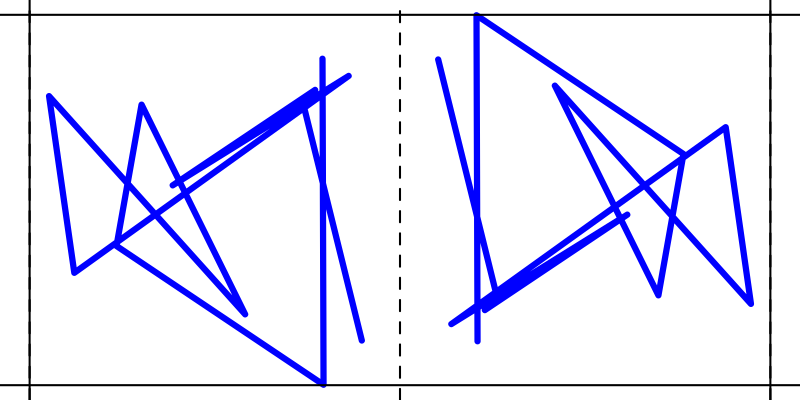

## Transformation 2

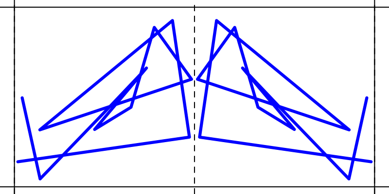

## Transformation 3

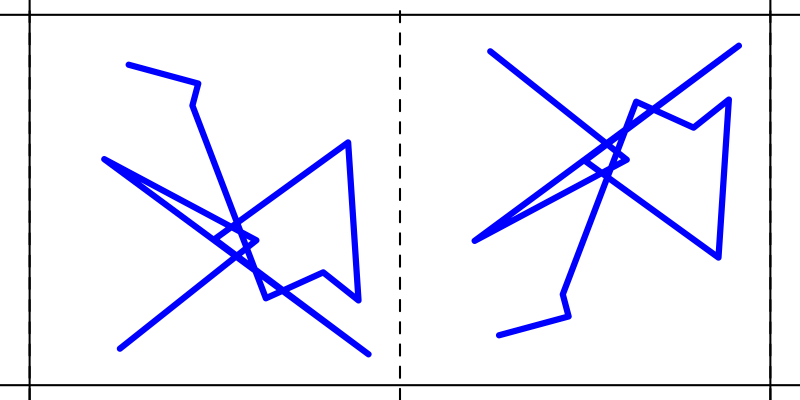

## Transformation 4

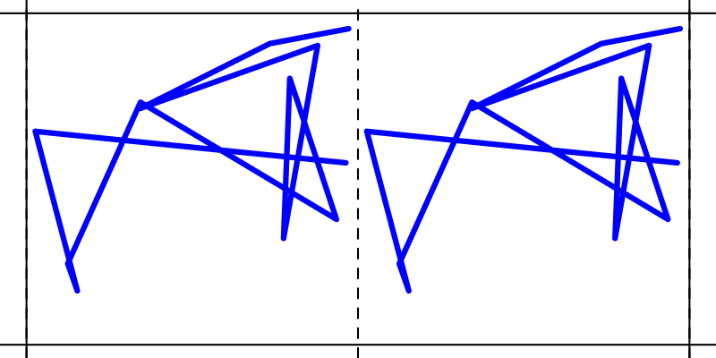

- Transformation 1: rotation.
- Transformation 2: mirror.
- Transformation 3: glide.
- Transformation 4: translation.

2, 4, 3, 1

There are 4 basic transformations in Frieze groups:

- Translation
- Rotation (by 180$^\circ$)
- Glide reflection (reflect vertically then translate horizontally)
- Mirror (reflect horizontally)

Label the four transformations below:

## Transformation 1

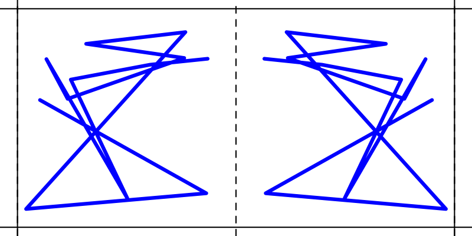

## Transformation 2

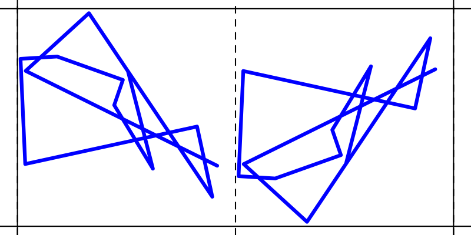

## Transformation 3

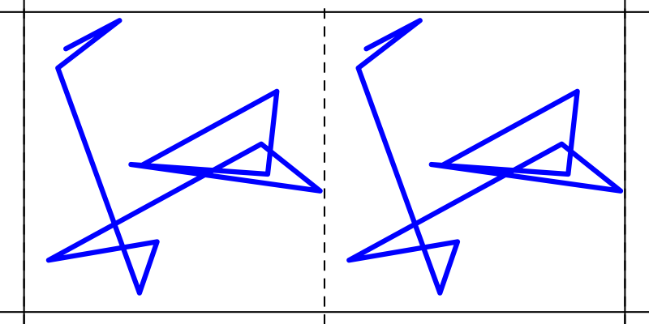

## Transformation 4

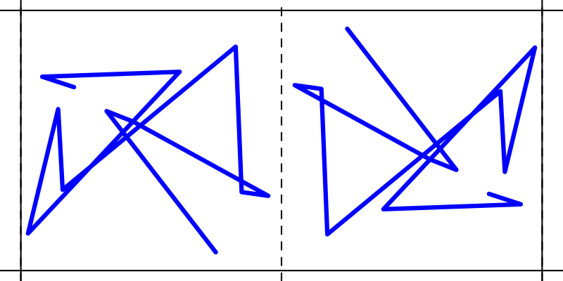

- Transformation 1: mirror.
- Transformation 2: glide.
- Transformation 3: translation.
- Transformation 4: rotation.

4, 3, 1, 2

There are 4 basic transformations in Frieze groups:

- Translation
- Rotation (by 180$^\circ$)
- Glide reflection (reflect vertically then translate horizontally)
- Mirror (reflect horizontally)

Label the four transformations below:

## Transformation 1

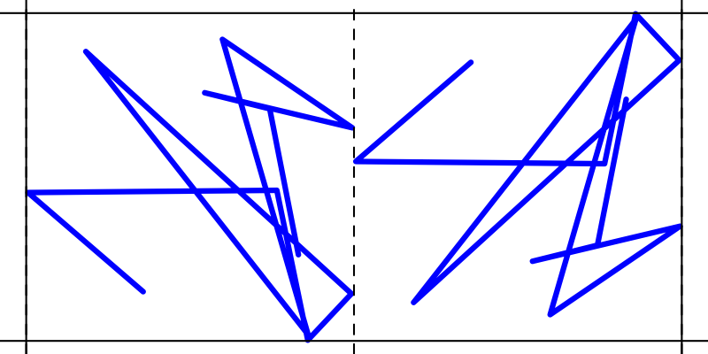

## Transformation 2

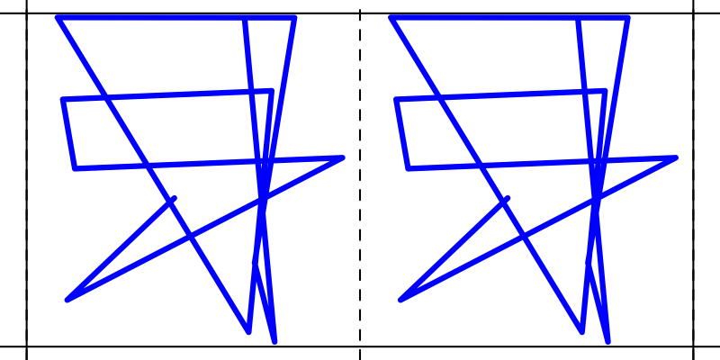

## Transformation 3

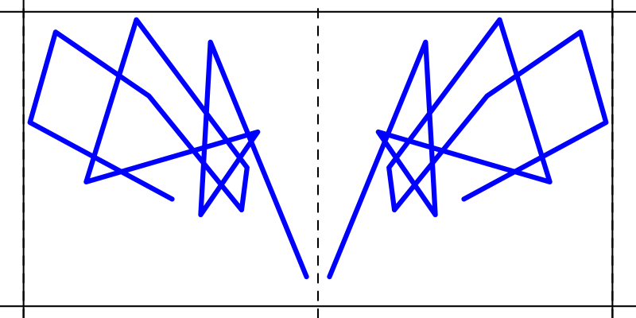

## Transformation 4

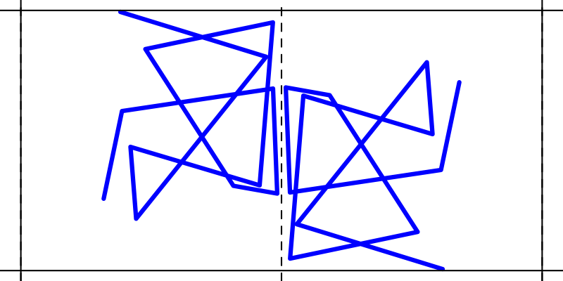

- Transformation 1: glide.
- Transformation 2: translation.
- Transformation 3: mirror.
- Transformation 4: rotation.

3, 1, 4, 2

There are 4 basic transformations in Frieze groups:

- Translation
- Rotation (by 180$^\circ$)
- Glide reflection (reflect vertically then translate horizontally)
- Mirror (reflect horizontally)

Label the four transformations below:

## Transformation 1

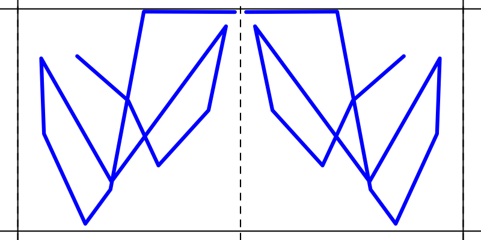

## Transformation 2

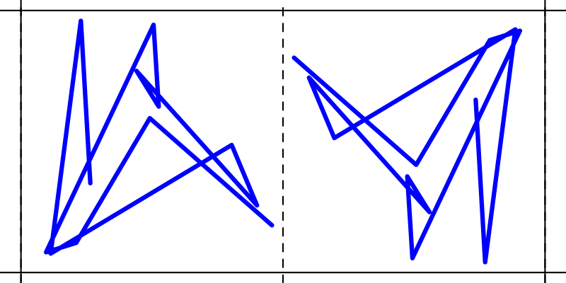

## Transformation 3

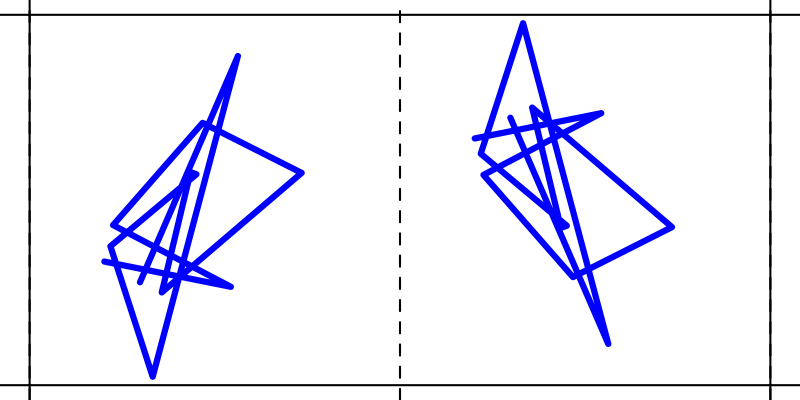

## Transformation 4

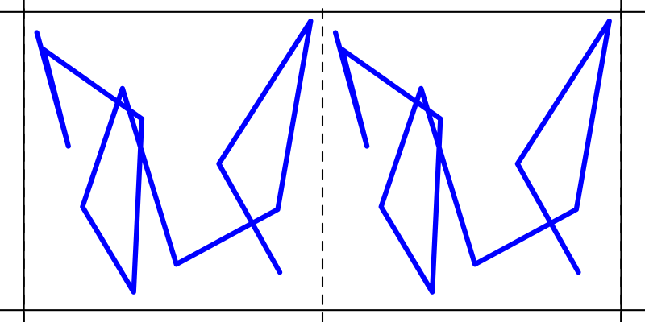

- Transformation 1: mirror.
- Transformation 2: rotation.
- Transformation 3: glide.
- Transformation 4: translation.

4, 2, 3, 1

There are 4 basic transformations in Frieze groups:

- Translation
- Rotation (by 180$^\circ$)
- Glide reflection (reflect vertically then translate horizontally)
- Mirror (reflect horizontally)

Label the four transformations below:

## Transformation 1

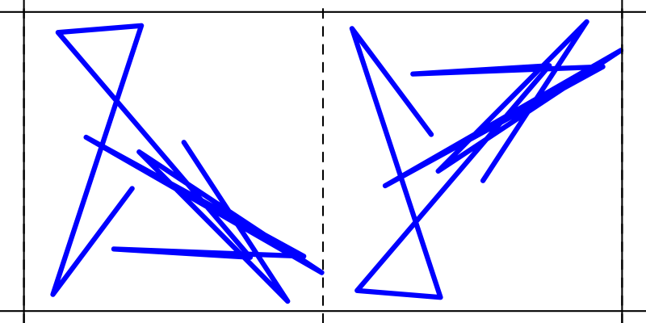

## Transformation 2

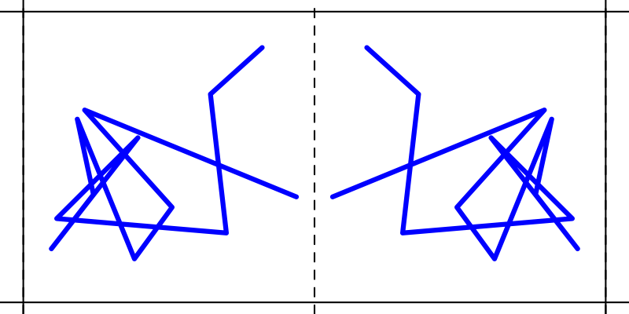

## Transformation 3

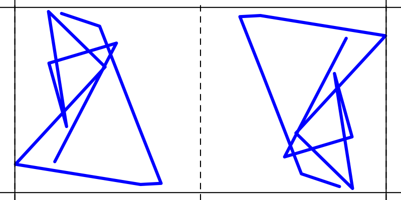

## Transformation 4

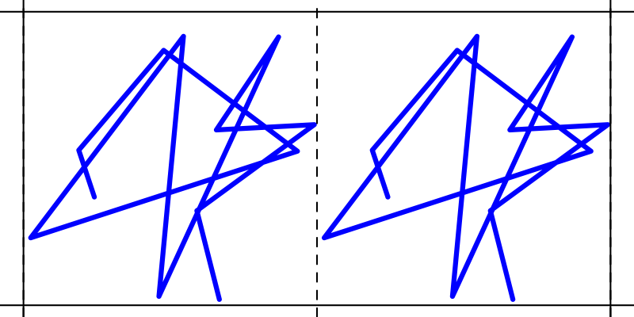

- Transformation 1: glide.
- Transformation 2: mirror.
- Transformation 3: rotation.
- Transformation 4: translation.

3, 4, 2, 1

There are 4 basic transformations in Frieze groups:

- Translation
- Rotation (by 180$^\circ$)
- Glide reflection (reflect vertically then translate horizontally)
- Mirror (reflect horizontally)

Label the four transformations below:

## Transformation 1

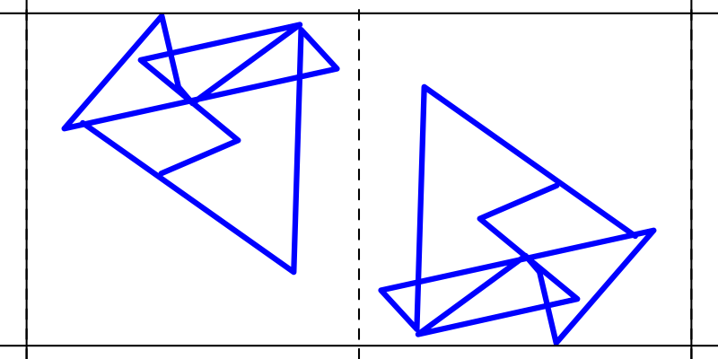

## Transformation 2

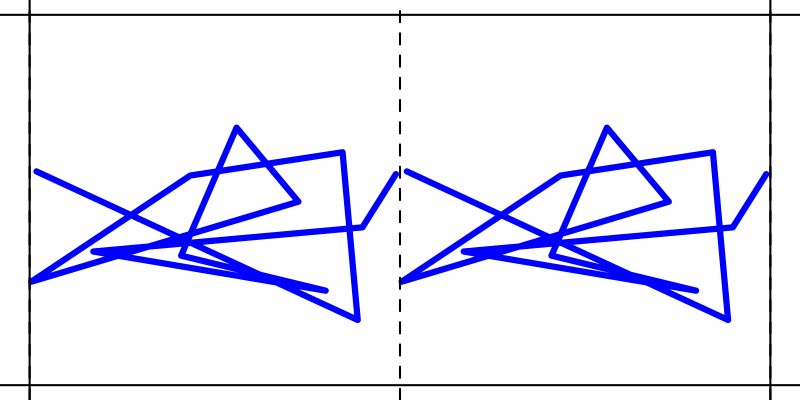

## Transformation 3

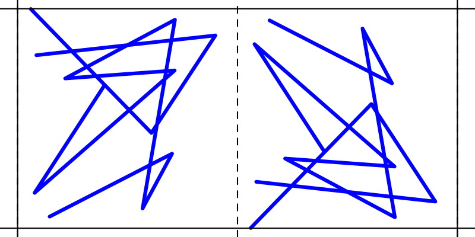

## Transformation 4

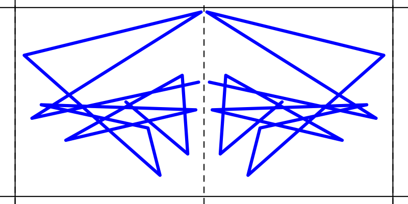

- Transformation 1: rotation.
- Transformation 2: translation.
- Transformation 3: glide.
- Transformation 4: mirror.

2, 1, 3, 4

There are 4 basic transformations in Frieze groups:

- Translation
- Rotation (by 180$^\circ$)
- Glide reflection (reflect vertically then translate horizontally)
- Mirror (reflect horizontally)

Label the four transformations below:

## Transformation 1

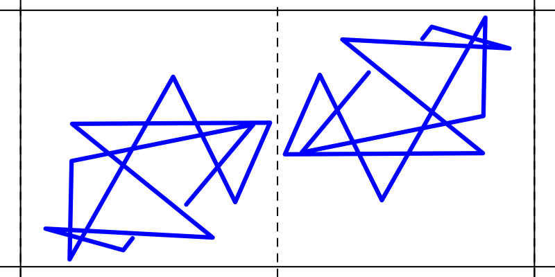

## Transformation 2

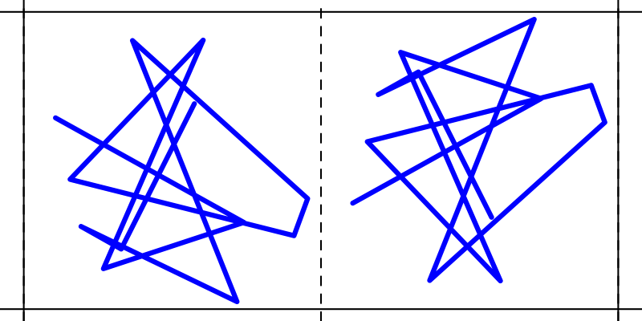

## Transformation 3

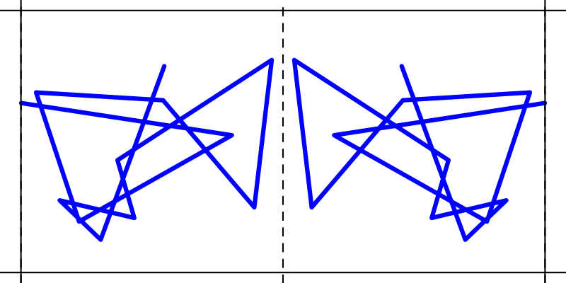

## Transformation 4

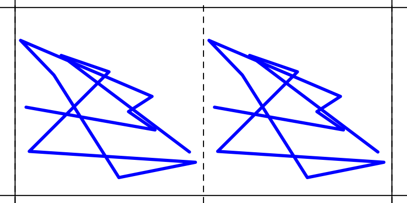

- Transformation 1: rotation.
- Transformation 2: glide.
- Transformation 3: mirror.
- Transformation 4: translation.

2, 3, 4, 1

There are 4 basic transformations in Frieze groups:

- Translation
- Rotation (by 180$^\circ$)
- Glide reflection (reflect vertically then translate horizontally)
- Mirror (reflect horizontally)

Label the four transformations below:

## Transformation 1

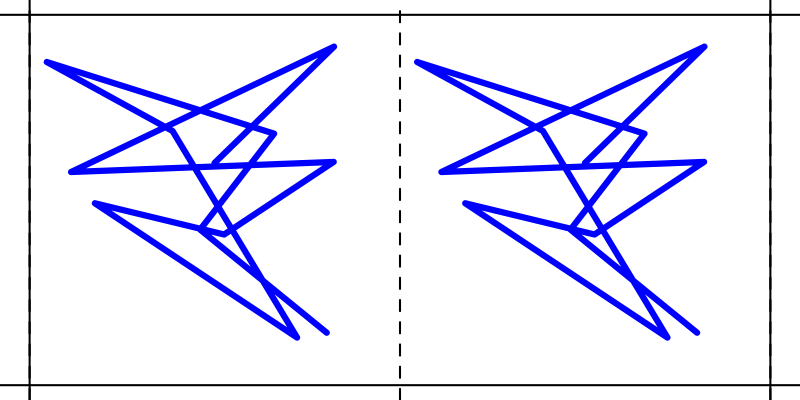

## Transformation 2

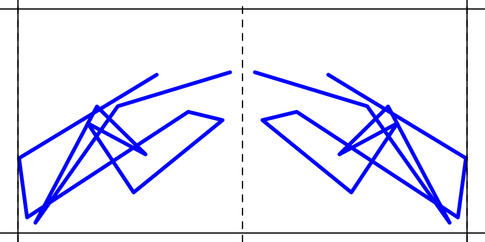

## Transformation 3

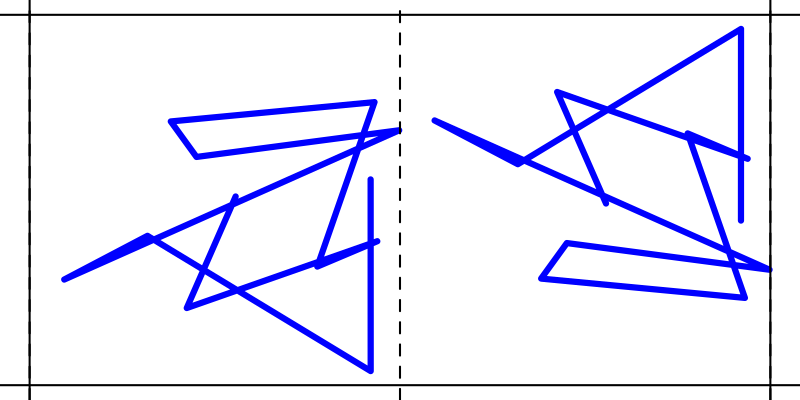

## Transformation 4

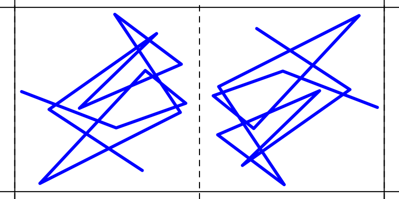

- Transformation 1: translation.
- Transformation 2: mirror.
- Transformation 3: glide.
- Transformation 4: rotation.

1, 4, 3, 2

There are 4 basic transformations in Frieze groups:

- Translation
- Rotation (by 180$^\circ$)
- Glide reflection (reflect vertically then translate horizontally)
- Mirror (reflect horizontally)

Label the four transformations below:

## Transformation 1

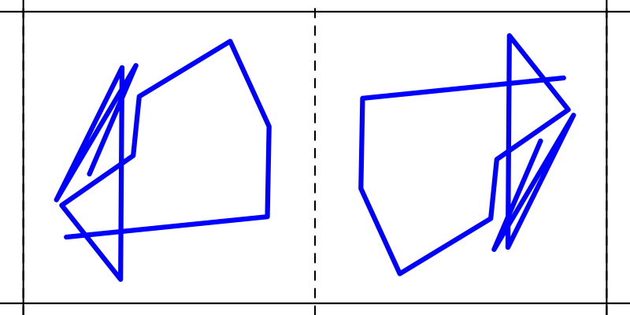

## Transformation 2

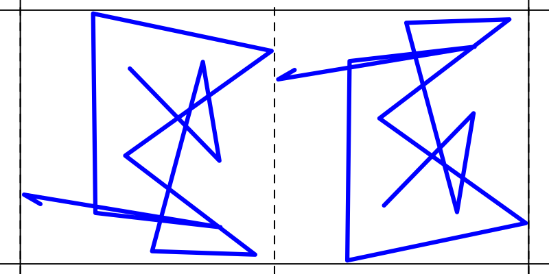

## Transformation 3

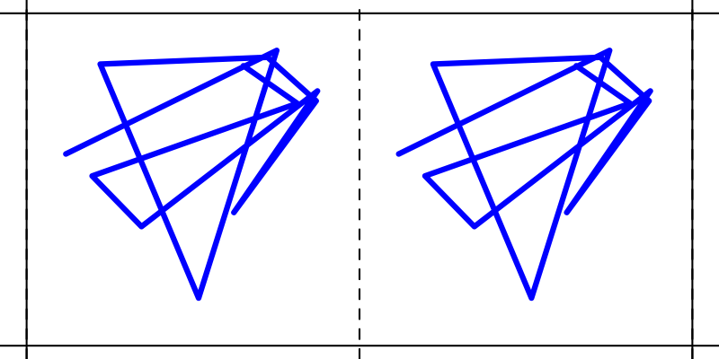

## Transformation 4

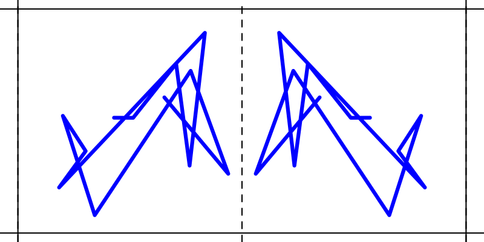

- Transformation 1: rotation.
- Transformation 2: glide.
- Transformation 3: translation.
- Transformation 4: mirror.

2, 3, 1, 4

There are 4 basic transformations in Frieze groups:

- Translation
- Rotation (by 180$^\circ$)
- Glide reflection (reflect vertically then translate horizontally)
- Mirror (reflect horizontally)

Label the four transformations below:

## Transformation 1

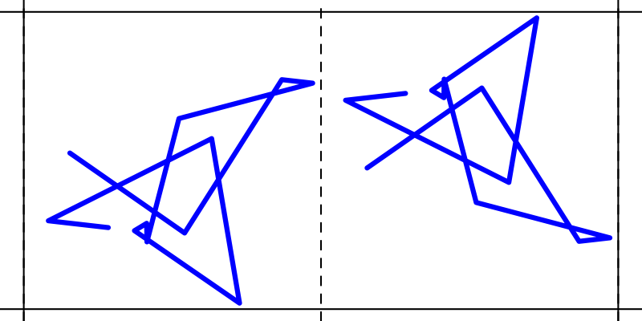

## Transformation 2

[figure not shown]

## Transformation 3

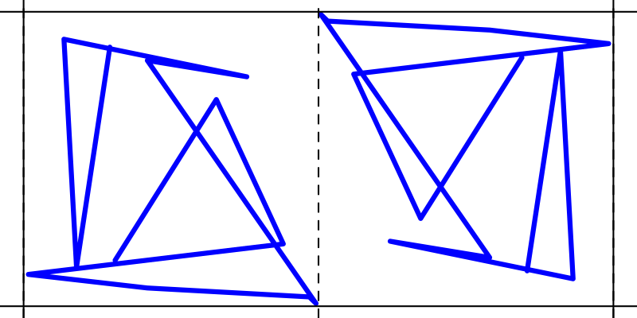

## Transformation 4

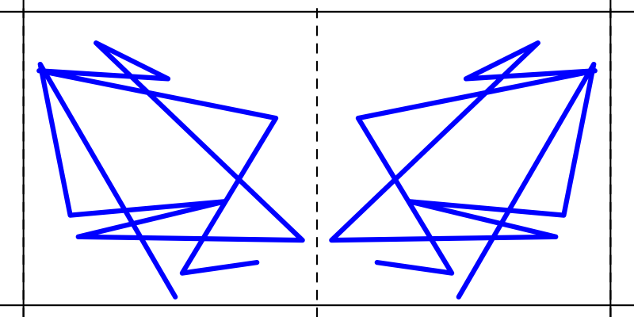

- Transformation 1: glide.
- Transformation 2: translation.
- Transformation 3: rotation.
- Transformation 4: mirror.

3, 1, 2, 4